# Assignment 2: Fancier Sokoban

Introduction to Programming (CSSE7030)  
**Due: 22 May 2026, 15:00 GMT+10**

Published

April 23, 2026

## Introduction

[Sokoban](https://www.mathsisfun.com/games/sokoban.html) is a simple puzzle game by Hiroyuki Imabayashiin, in which a player tries to push crates onto goal locations in a grid. In assignment 2, you will create a slightly modified text-based version of Sokoban, in which the player may also need to collect potions in order to be able to push all crates to goal locations within an allocated number of moves.

## Getting Started

Download `a2.zip` from Blackboard. This archive contains the necessary files to start your assignment. Once extracted, the `a2.zip` archive will provide the following files:

- `a2.py`: *This is the only file where you write your code* and is the *only* `.py` file you will submit. *Do not* make changes to any other files.
- `support.py`: *Do not modify or submit this file*, it contains pre-defined constants to use in your assignment. In addition to these, you are encouraged to create your own constants in `a2.py` where possible.
- `gameplay/`: This folder contains a number of example outputs generated by playing the game using a fully-functional completed solution to this assignment. The purpose of the files in this folder is to help you understand how the game works, and how output should be formatted.
- `levels/`: This folder contains a collection of files that can be used to initialise games of Sokoban.

If you also wish to download this task sheet you must first click `View Fullscreen` at the top of the page. This will open the task sheet in a new browser tab. On this tab, use `Ctrl-P` to print the page, and select `Save to PDF` as the output location. The print button on Blackboard only captures the first two or so pages of this sheet (a limitation of Blackboard beyond our control).

**Caution**

The task sheet may be modified throughout the course of the assignment as issues are identified. These updates will appear online, but will **not** be reflected in a previously downloaded copy. Please regularly check the changelog **online** to ensure you are working with the most up to date version of the task sheet.

## Gameplay

This section provides a high-level overview of gameplay, and is intended to provide you with an idea of the behaviour of a fully completed assignment. Where interactions are not explicitly mentioned in this section, please see the Implementation section.

**Important**

Do not simply implement the behaviour described here using your own structure; you *must* implement the individual functions, classes, and methods described in the Implementation section. Inputs and outputs must match *exactly* what is expected. Refer to the Implementation section, the given examples, and the provided Gradescope tests for clarification on required prompts and outputs.

In Fancier Sokoban, a player appears in a *maze*, which is made up of *tiles*. Tiles may be a *wall*, *floor*, or *goal*. There are also a number of movable *entities* that exist on the maze. The *player* is themselves an entity. Other entities include *crates* and various types of *potions*. The objective of the game is for the player to push the crates onto the goal locations such that every goal tile is *filled* (covered by a crate). Every game has exactly as many crates as it has goals. The player cannot move through a wall. A crate cannot move through a wall or through any other entity (including other crates). The player attempts to move exactly one square up, down, left, or right on any given move. If the player cannot move into a given position, they are returned to the position they attempted to move from.

The player has a limited number of moves available, and starts with an initial *strength*. Each crate has an associated *weight*, which represents the strength required to push them. When the player moves onto a position containing a crate, they attempt to push it. If the player has equal or greater strength than the crate’s weight, and the crate can move one square in the direction the player is moving, the crate moves one square in that direction and the player takes the crate’s original position.

Potions are collectable entities which have a number of *effects* that can be applied to increase a player’s strength and/or number of moves remaining, thereby allowing them to complete games they may otherwise be unable to complete. When the player moves onto a position containing a potion, the potion’s effects are applied to the player and the potion is then removed from the game. Each effect is applied with a value, which denotes how strong the effect is. The behavior of each effect is given in Table 1.

Table 1: Potion effects. Effects with names that do not *exactly* match a row on this table do nothing.

| Effect | Behavior |
| --- | --- |
| `strength` | The player’s strength is increased by the effect value. |
| `moves` | The player’s available moves is increased by the effect value. |

After starting a game of Fancier Sokoban, the initial game state is printed to the screen, and the following game loop then occurs:

1. The player is prompted to enter a command using `MOVE_PROMPT` from `support.py`. Valid commands are given in Table 2.
2. If the player entered a valid command, an action is attempted as described in Table 2.
3. If an action was not successfully completed, `INVALID_MSG` from `support.py` is printed.
4. The display is updated by printing the current game state to the screen.
5. If the game is not over, gameplay returns to step 1. Otherwise gameplay advances to step 6.
6. Either `WIN_MSG` or `LOSE_MSG` from `support.py` is printed to the screen informing the player that they won or lost the game as appropriate.
7. The program terminates gracefully.

When a game of Fancier Sokoban begins, the initial game state is displayed. The player is then prompted for a move. Players enter their desired move using a single character; Valid moves and their corresponding behaviors are given in Table 2. If the player enters an invalid move, `INVALID_MSG` from `support.py` is displayed. The player’s remaining moves are only decremented after the player successfully moves to a new position; if the player did not successfully move to a new position after a move, `INVALID_MSG` from `support.py` should be displayed. The display of the game state followed by the player entering a move is then repeated until one of the following occurs and the game is over:

- The player *wins* when all goals in the maze are filled.
- The player *loses* when they runout of available moves and not all goals in the maze are filled.

Once the game is over, the player is informed if they won or lost, and the program then terminates gracefully.

Table 2: Valid moves and their corresponding behavior. If the user does not enter a character *exactly* matching a row on this table, no action is attempted.

| Move | Behavior |
| --- | --- |
| `w`/`W` | The player attempts to move up one square. |
| `a`/`A` | The player attempts to move left one square. |
| `s`/`S` | The player attempts to move down one square. |
| `d`/`D` | The player attempts to move right one square. |
| `q`/`Q` | The program immediately terminates gracefully |

## Implementation

**Important**

You are **not** permitted to add any additional import statements to `a2.py`. Doing so will result in a deduction of up to 100% of your mark. You must not modify or remove the import statements already provided to you in `a2.py`. Removing or modifying these existing import statements may result in your code not functioning, and may result in a deduction of up to 100% of your mark.

### Required Classes and Methods

This section outlines the classes and methods you are **required** to implement in `a2.py`. Your program must operate *exactly* as specified. In particular, your program’s output must match *exactly* with the expected output. Your program will be marked automatically so minor differences in output (such as whitespace or casing) *will* cause tests to fail resulting in *zero marks* for that test.

The class diagram in Figure 1 provides an overview of all of the classes you must implement in your assignment, and the basic relationships between them. The details of these classes and their methods are described in depth later in this section. Within Figure 1:

- Green classes are abstract classes (superclasses). However, you are not required to enforce the abstract nature of the green classes in their implementation. The purpose of this distinction is to indicate to you that you should only ever instantiate the blue classes in your program (though you should instantiate the green classes to test them before beginning work on their subclasses).
- Blue classes are concrete classes (subclasses).
- Solid arrows indicate inheritance (i.e. the “is-a” relationship).
- Dotted arrows indicate composition (i.e. the “has-a” relationship). An arrow marked with 1-1 denotes that each instance of the class at the base of the arrow contains exactly one instance of the class at the head of the arrow. An arrow marked with 1-N denotes that each instance of the class at the base of the arrow may contain many instances of the class at the head of the arrow.

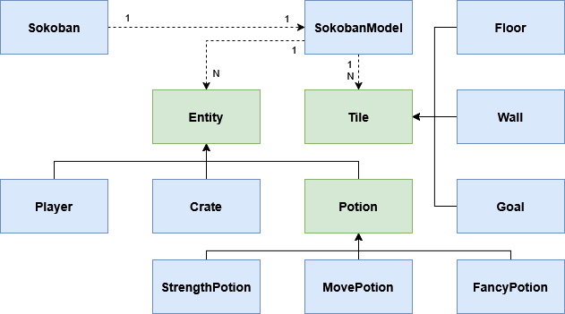

Figure 1: Basic UML diagram for the classes in assignment 2.

**Note**

You are awarded marks for the number of tests passed by your classes when they are tested *independently* of one another. Thus an incomplete assignment with *some* working classes may well be awarded more marks than a complete assignment with faulty classes.

Each class is accompanied with some examples for usage to help you *start* your own testing. You should also test your methods with other values to ensure they operate according to the descriptions.

The rest of this section describes what you must implement in `a2.py` in detail. We recommend that you complete the given tasks in order, ensuring that everything you implement is tested thoroughly, operating correctly, and passes all relevant Gradescope tests.

**Note**

In the following tasks, you will encounter the `Maze` and `Position` types. These are simply aliases for `list[list[Tile]]` and `tuple[int, int]` used for readability, and are defined in `support.py`

#### Task 1 `Tile()`

`Tile` is an abstract class from which all instantiated types of tile inherit. This class provides default tile behavior, which can be inherited or overridden by specific types of tile. All tiles are given a single character identifier representing their type, and can either be blocking, or not blocking.

Abstract tiles are not blocking, and have type representation `T`.

`Tile` must implement the following methods:

- `__init__(self)`  
  Instantiate a new tile.
- `__str__(self) -> str`  
  Returns the single character representing this tile. Unless otherwise specified, this will be the tile’s type representation.
- `__repr__(self) -> str`  
  Returns a string which could be copied and pasted into a REPL to construct a new instance identical to self.
- `get_type(self) -> str` Returns the single character representing the type of this tile.
- `is_blocking(self) -> bool`  
  Returns if this tile is blocking or not.

Example:

```python
>>> tile = Tile()
>>> tile
```

```
Tile()
```

```python
>>> str(tile)
```

```
'T'
```

```python
>>> tile.get_type()
```

```
'T'
```

```python
>>> tile.is_blocking()
```

```
False
```

#### Task 2 `Floor(Tile)`

`Floor` is a non-blocking tile representing empty space on which entities can freely move. Floor tiles are given a type identifier of a single space ().

Example:

```python
>>> tile = Floor()
>>> tile
```

```
Floor()
```

```python
>>> str(tile)
```

```
' '
```

```python
>>> tile.get_type()
```

```
' '
```

```python
>>> tile.is_blocking()
```

```
False
```

#### Task 3 `Wall(Tile)`

`Wall` is a blocking tile representing a barrier impassable to entities. Wall tiles are given type identifier `W`.

Example:

```python
>>> tile = Wall()
>>> tile
```

```
Wall()
```

```python
>>> str(tile)
```

```
'W'
```

```python
>>> tile.get_type()
```

```
'W'
```

```python
>>> tile.is_blocking()
```

```
True
```

#### Task 4 `Goal(Tile)`

`Goal` is a type of tile that represents a goal location for a crate. Goal tiles are non-blocking, and the type is represented by `G`. Goal tiles can either be filled (i.e. contain a crate) or unfilled (i.e. empty, with room for one crate). Goal tiles start unfilled, and become filled throughout gameplay as the player pushes crates onto them.

In addition to the `Tile` methods that must be supported, `Goal` must implement the following methods:

- `__str__(self) -> str`  
  Returns the single character representing this tile. `Goal` tiles are represented by `X` when filled, and `G` otherwise.
- `is_filled(self) -> bool`  
  Return if this goal is currently filled.
- `fill(self)`  
  Fills this goal.
- `unfill(self)`  
  Unfills this goal.

Example:

```python
>>> goal = Goal()
>>> goal
```

```
Goal()
```

```python
>>> str(goal)
```

```
'G'
```

```python
>>> goal.is_blocking()
```

```
False
```

```python
>>> goal.get_type()
```

```
'G'
```

```python
>>> goal.is_filled()
```

```
False
```

```python
>>> goal.fill()
```

```python
>>> goal.is_filled()
```

```
True
```

```python
>>> str(goal)
```

```
'X'
```

```python
>>> goal.get_type()
```

```
'G'
```

```python
>>> goal.unfill()
```

```python
>>> goal.is_filled()
```

```
False
```

```python
>>> str(goal)
```

```
'G'
```

#### Task 5 `Entity()`

`Entity` is an abstract class from which all instantiated types of entity inherit. This class provides default entity behavior, which can be inherited or overridden by specific types of entity. Each entity occupies a position. Positions are represented as (row, column) integer tuples, where `(0, 0)` denotes the top-left corner of the maze. Like tiles, each entity is given a single character identifier representing its type. Base have type representation `E`.

`Entity` must implement the following methods:

- `__init__(self, position: Position)`  
  Instantiate a new entity at the given position.
- `__repr__(self) -> str`  
  Returns a string which could be copied and pasted into a REPL to construct a new instance identical to self.
- `__str__(self) -> str`  
  Returns the single character representing this entity. Unless otherwise specified, this will be the entity’s type representation.
- `get_type(self) -> str` Returns the single character representing the type of this entity.
- `get_position(self) -> Position`  
  Returns this entity’s position.
- `set_position(self, new_pos: Position)`  
  Sets this entity’s position to the specified value.

Example:

```python
>>> entity = Entity((0,1))
>>> entity
```

```
Entity((0, 1))
```

```python
>>> str(entity)
```

```
'E'
```

```python
>>> entity.get_type()
```

```
'E'
```

```python
>>> entity.get_position()
```

```
(0, 1)
```

```python
>>> entity.set_position((6,7))
>>> entity
```

```
Entity((6, 7))
```

```python
>>> entity.get_position()
```

```
(6, 7)
```

#### Task 6 `Potion(Entity)`

A `Potion` is an abstract class which provides a simple interface which all instances of potions must implement. Potion effects are represented using a dictionary mapping effect names to the value applied by the potion.

Abstract potions have type representation `O` and no effects.

In addition to the `Entity` methods that must be supported, `Potion` must implement the following methods:

- `effect(self)`  
  Returns this potion’s effect.

Example:

```python
>>> potion = Potion((0,1))
>>> potion
```

```
Potion((0, 1))
```

```python
>>> str(potion)
```

```
'O'
```

```python
>>> potion.get_type()
```

```
'O'
```

```python
>>> potion.get_position()
```

```
(0, 1)
```

```python
>>> potion.effect()
```

```
{}
```

#### Task 7 `StrengthPotion(Potion)`

A `StrengthPotion` is a foul tasting potion that provides the player with 2 `strength`. Strength potions have type representation `S`.

Example:

```python
>>> potion = StrengthPotion((0,1))
>>> potion
```

```
StrengthPotion((0, 1))
```

```python
>>> str(potion)
```

```
'S'
```

```python
>>> potion.get_type()
```

```
'S'
```

```python
>>> potion.get_position()
```

```
(0, 1)
```

```python
>>> potion.effect()
```

```
{'strength': 2}
```

#### Task 8 `MovePotion(Potion)`

A `MovePotion` is a fruity tasting potion that provides the player with 5 `moves`. Move potions have type representation `M`.

Example:

```python
>>> potion = MovePotion((0,1))
>>> potion
```

```
MovePotion((0, 1))
```

```python
>>> str(potion)
```

```
'M'
```

```python
>>> potion.get_type()
```

```
'M'
```

```python
>>> potion.get_position()
```

```
(0, 1)
```

```python
>>> potion.effect()
```

```
{'moves': 5}
```

#### Task 9 `FancyPotion(Potion)`

A `FancyPotion` is a vibrant vermilion potion that looks surely unsafe for human consumption. Nonetheless, a fancy potion provides both 2 `strength` and 2 `moves` (Very Fancy). Fancy Potions have type representation `F`.

Example:

```python
>>> potion = FancyPotion((0,1))
>>> potion
```

```
FancyPotion((0, 1))
```

```python
>>> str(potion)
```

```
'F'
```

```python
>>> potion.get_type()
```

```
'F'
```

```python
>>> potion.get_position()
```

```
(0, 1)
```

```python
>>> potion.effect()
```

```
{'strength': 2, 'moves': 2}
```

#### Task 10 `Crate(Entity)`

A `Crate` is an entity the player can push around the Maze. Crates possess a weight value representing the strength a player is required to have in order to move it. You may assume that a crate’s weight will always be a non-negative, single digit integer. Crates have type identifier `C`.

**Note**

Blocking players from moving crates that they are not strong enough to move should not be handled by the crate class. A crate only needs to be aware of its own strength requirement, and provide an interface through which the model class can access that information.

To support this extended functionality, the `__init__` method of `Crate` takes in an additional argument. In addition to the `Entity` methods that must be supported, `Crate` must implement the following methods:

- `__init__(self, position: Position, weight: int)`  
  Instantiate a new crate of specified weight at the given position.
- `__str__(self) -> str`  
  Returns a string containing this crate’s weight.
- `get_weight(self) -> int`  
  Returns this crate’s weight.

Example:

```python
>>> crate = Crate((0,1), 6)
>>> crate
```

```
Crate((0, 1), 6)
```

```python
>>> str(crate)
```

```
'6'
```

```python
>>> crate.get_type()
```

```
'C'
```

```python
>>> crate.get_position()
```

```
(0, 1)
```

```python
>>> crate.get_weight()
```

```
6
```

#### Task 11 `Player(Entity)`

`Player` denotes the entity directly controlled by the player. Player entities possess both a strength value and a number of remaining turns. These values will change throughout regular gameplay. Player instances have type identifier `P`.

To support this extended functionality, The `__init__` method of `Player` takes in two additional arguments. In addition to the `Entity` methods that must be supported, `Player` must implement the following methods:

- `__init__(self, position: Position, strength: int, moves_remaining: int)`  
  Instantiate a new player at the given position, with the specified strength and moves.
- `get_strength(self) -> int`  
  Return this player’s current strength.
- `add_strength(self, strength: int)`  
  Add the given strength to this player instance.
- `get_moves_remaining(self) -> int`  
  Return the number of remaining moves this player has.
- `add_moves_remaining(self, moves: int)`  
  Add the given number of moves to the remaining count of this player instance.
- `apply_effect(self, potion_effect: dict[str, int])`  
  Apply the given potion effects as per Table 1.

Example:

```python
>>> player = Player((0,1), 4, 2)
>>> player
```

```
Player((0, 1), 4, 2)
```

```python
>>> str(player)
```

```
'P'
```

```python
>>> player.get_type()
```

```
'P'
```

```python
>>> player.get_position()
```

```
(0, 1)
```

```python
>>> player.get_strength()
```

```
4
```

```python
>>> player.add_strength(6)
>>> player
```

```
Player((0, 1), 10, 2)
```

```python
>>> player.get_strength()
```

```
10
```

```python
>>> player.get_moves_remaining()
```

```
2
```

```python
>>> player.add_moves_remaining(9)
>>> player
```

```
Player((0, 1), 10, 11)
```

```python
>>> player.get_moves_remaining()
```

```
11
```

```python
>>> player.apply_effect({})
>>> player
```

```
Player((0, 1), 10, 11)
```

```python
>>> player.get_strength()
```

```
10
```

```python
>>> player.get_moves_remaining()
```

```
11
```

```python
>>> player.apply_effect({
    'strength': -4,
    'moves': 20
})
>>> player
```

```
Player((0, 1), 6, 31)
```

```python
>>> player.get_strength()
```

```
6
```

```python
>>> player.get_moves_remaining()
```

```
31
```

#### Task 12 `read_file(maze_file: str) -> tuple[Maze, list[Entity], Player]`

`read_file` is a helpful *function* that loads from a text file a maze, player, and the other entities comprising a game of Fancier Sokoban.

You may assume that the file specified by `maze_file` contains *exactly* the following:

- A single line containing exactly two integers, corresponding to the player’s strength and remaining moves in that order. This is followed immediately by:
- A rectangular grid of single characters, denoting the maze and the entities contained within it.

Within the rectangular grid the character at each position is the string representation of the tile at that position within the maze. If there is an entity at a given position within the maze, the character at that position in the rectangular grid is instead the string representation of that entity. You may (and indeed must) assume that all entities present in the maze are located on `Floor` tiles.

The list of entities that you return should not include the player entity, and should be ordered by entity position: from top to bottom with ties being broken from left to right.

**Tip**

The `levels/` folder contains examples of files that this function is expected to parse.

Example:

```python
>>> maze, entities, player = read_file('levels/level3.txt')
>>> maze
```

```
[[Wall(), Wall(), Wall(), Wall(), Wall(), Wall(), Wall(), Wall()],
 [Wall(), Floor(), Floor(), Floor(), Wall(), Floor(), Floor(), Wall()],
 [Wall(), Floor(), Floor(), Floor(), Wall(), Floor(), Floor(), Wall()],
 [Wall(), Floor(), Floor(), Floor(), Wall(), Goal(), Floor(), Wall()],
 [Wall(), Floor(), Floor(), Floor(), Floor(), Floor(), Floor(), Wall()],
 [Wall(), Floor(), Floor(), Floor(), Floor(), Floor(), Goal(), Wall()],
 [Wall(), Wall(), Wall(), Wall(), Wall(), Wall(), Wall(), Wall()]]
```

```python
>>> entities
```

```
[FancyPotion((2, 2)),
 Crate((3, 2), 4),
 StrengthPotion((4, 4)),
 Crate((5, 2), 3)]
```

```python
>>> player
```

```
Player((1, 1), 1, 23)
```

#### Task 13 `SokobanModel()`

The `SokobanModel` class is responsible for maintaining the game state, and applying game logic.

Within this model, a valid direction is one of the valid move formats given in Table 2 except for the last row. We also refer to the ‘entity order’ which is given by the order of the entity list passed to the constructor. This helps makes sure that your outputs exactly match what gradescope is expecting.

`Sokoban` must implement the following methods:

- `__init__(self, maze: Maze, entities: list[Entity], player: Player)`  
  Instantiates a new `SokobanModel` using the given maze, entities, and player. The list of entities defines the entity order.
- `get_maze(self) -> Maze`  
  Return this model’s maze.
- `get_entities(self) -> list[Entity]`  
  Return this model’s non-player entities, in entity order.
- `get_player(self) -> Player`  
  Return this model’s player instance.
- `entity_positions(self) -> dict[Position, Entity]`  
  Returns a dictionary mapping the position of each non-player entity to the corresponding entity instance. To ensure you have minimum issues with Gradescope, you should construct this dictionary in entity order.
- `has_lost(self) -> bool`  
  Return `True` if the player has lost the game per the Gameplay section, and `False` otherwise.
- `has_won(self) -> bool`  
  Return `True` if the player has won the game per the Gameplay section, and `False` otherwise.
- `shove_crate(self, crate: Crate, direction: str) -> bool`  
  Attempts to move the given crate in the specified direction as per the rules given in the Gameplay section. The crate will not move if `direction` is not a valid direction. Returns a boolean specifying if the given crate was moved or not.
- `attempt_move(self, direction: str) -> bool`  
  Attempts to move the player in the specified direction as per the rules given in the Gameplay section. The player will not move if `direction` is not a valid direction. Returns a boolean specifying if the player successfully moved to a new position.

**Caution**

Some of these methods will become *very long*. You will likely benefit from adding extra helper methods to this class to help break up some of these long methods.

Example:

```python
>>> maze, entities, player = read_file('levels/level3.txt')
>>> model = SokobanModel(maze, entities, player)
>>> model.get_maze()
```

```
[[Wall(), Wall(), Wall(), Wall(), Wall(), Wall(), Wall(), Wall()],
 [Wall(), Floor(), Floor(), Floor(), Wall(), Floor(), Floor(), Wall()],
 [Wall(), Floor(), Floor(), Floor(), Wall(), Floor(), Floor(), Wall()],
 [Wall(), Floor(), Floor(), Floor(), Wall(), Goal(), Floor(), Wall()],
 [Wall(), Floor(), Floor(), Floor(), Floor(), Floor(), Floor(), Wall()],
 [Wall(), Floor(), Floor(), Floor(), Floor(), Floor(), Goal(), Wall()],
 [Wall(), Wall(), Wall(), Wall(), Wall(), Wall(), Wall(), Wall()]]
```

```python
>>> model.get_player()
```

```
Player((1, 1), 1, 23)
```

```python
>>> model.get_entities()
```

```
[FancyPotion((2, 2)),
 Crate((3, 2), 4),
 StrengthPotion((4, 4)),
 Crate((5, 2), 3)]
```

```python
>>> model.entity_positions()
```

```
{(2, 2): FancyPotion((2, 2)),
 (3, 2): Crate((3, 2), 4),
 (4, 4): StrengthPotion((4, 4)),
 (5, 2): Crate((5, 2), 3)}
```

```python
>>> model.has_won()
```

```
False
```

```python
>>> model.has_lost()
```

```
False
```

```python
>>> model.get_player().add_moves_remaining(-23)
>>> model.get_player().get_moves_remaining() <= 0
```

```
True
```

```python
>>> model.has_won()
```

```
False
```

```python
>>> model.has_lost()
```

```
True
```

```python
>>> maze = model.get_maze()
>>> maze[3][5].fill() # First goal
>>> maze[-2][-2].fill() # Second goal
```

```python
>>> model.has_won()
```

```
True
```

```python
>>> model.has_lost()
```

```
False
```

```python
>>> model.get_player()
```

```
Player((1, 1), 1, 0)
```

```python
>>> model.attempt_move('a') # Move into wall
```

```
False
```

```python
>>> model.get_player()
```

```
Player((1, 1), 1, 0)
```

```python
>>> model.attempt_move('amogus') # Invalid direction
```

```
False
```

```python
>>> model.get_player()
```

```
Player((1, 1), 1, 0)
```

```python
>>> model.attempt_move('d') # Move right
```

```
True
```

```python
>>> model.get_player()
```

```
Player((1, 2), 1, -1)
```

```python
>>> model.attempt_move('s') # Move onto fancy potion
```

```
True
```

```python
>>> model.get_entities()
```

```
[Crate((3, 2), 4), StrengthPotion((4, 4)), Crate((5, 2), 3)]
```

```python
>>> model.get_player()
```

```
Player((2, 2), 3, 0)
```

```python
>>> e = model.get_entities()
>>> c1 = e[0] # First Crate
>>> c2 = e[2] # Second Crate
>>> c1, c2
```

```
(Crate((3, 2), 4), Crate((5, 2), 3))
```

```python
>>> model.shove_crate(c1, 's') # Too heavy
```

```
False
```

```python
>>> model.shove_crate(c2, 'w') # Shove up to under first crate
```

```
True
```

```python
>>> model.get_player().add_strength(99)
```

```python
>>> model.attempt_move('s') # c2 in the way of c1
```

```
False
```

```python
>>> model.shove_crate(c2, 'a') # Shove out of way
```

```
True
```

```python
>>> player, c1 # Lined up
```

```
(Player((2, 2), 102, 0), Crate((3, 2), 4))
```

```python
>>> model.attempt_move('s') # player moves c1 down.
```

```
True
```

```python
>>> player, c1
```

```
(Player((3, 2), 102, -1), Crate((4, 2), 4))
```

```python
>>> model.entity_positions()
```

```
{(4, 2): Crate((4, 2), 4),
 (4, 4): StrengthPotion((4, 4)),
 (4, 1): Crate((4, 1), 3)}
```

#### Task 14 `Sokoban()`

`Sokoban` represents a complete game of Fancier Sokoban. This class is responsible for handling input and output in order to play a game from start to end.

`Sokoban()` should implement the following methods:

- `__init__(self, maze_file: str)`  
  Constructs a new `Sokoban` instance, including loading the game state from the specified file and constructing a corresponding `SokobanModel`.
- `display(self)`  
  Prints the current game state to the screen in a visually appealing format. The display should contain a rectangular grid of characters representing the maze, as would be seen in a level file, followed by the player’s remaining moves and strength. The exact format expected by gradescope is given in the examples present in the `gameplay/` folder. You should make use of the `display_game` helper function provided in `support.py`.
- `play(self)`  
  Conducts a game of *Fancier Sokoban* from start to finish, following the Gameplay section. See the `gameplay/` folder for example output from this method.

#### Task 15 `play_game(file: str)`

The play game function should be fairly short and do *exactly* two things:

1. Construct a `Sokoban` instance using the given game file.
2. Play a single game of *Fancier Sokoban* from beginning to end (using `.play()`)

#### Task 16 `main()`

The purpose of the main function is to allow you to test your own code. Like the play game function, the main function should be short (A single line) and do exactly one thing: call `play_game` with a file name of your choice.

## Assessment and Marking Criteria

This assignment assesses following course learning objectives:

1. Apply program constructs such as variables, selection, iteration and sub-routines,
2. Apply basic object-oriented concepts such as classes, instances and methods,
3. Read and analyse code written by others,
4. Analyse a problem and design an algorithmic solution to the problem,
5. Read and analyse a design and be able to translate the design into a working program, and
6. Apply techniques for testing and debugging.

There are a total of 100 marks for this assessment item.

### Functionality

Your program’s functionality will be marked out of a total of 55 marks.

Your assignment will be put through a series of tests and your functionality mark will be proportional to the number of tests you pass. You will be given a *subset* of the functionality tests before the due date for the assignment.

You may receive partial marks within each section for partially working functions, or for implementing only a few functions.

**Warning**

You need to perform your *own* testing of your program to make sure that it meets **all** specifications given in the assignment. Only relying on the provided tests is likely to result in your program failing in some cases and you losing some functionality marks.

**Note**

Functionality tests are automated, so string outputs need to match *exactly* what is expected.

Your program must run in Gradescope, which uses Python 3.12. Partial solutions will be marked but if there are errors in your code that cause the interpreter to fail to execute your program, you will get zero for functionality marks. If there is a part of your code that causes the interpreter to fail, comment out the code so that the remainder can run. Your program must run using the Python 3.12 interpreter. If it runs in another environment (e.g. Python 3.8 or PyCharm) but not in the Python 3.12 interpreter, you will get zero for the functionality mark. Python versions newer than 3.12 will function correctly provided you do not use language features that are not introduced in the course.

### Code Style

The style of your assignment will be assessed by a tutor. Style will be marked according to the style rubric provided with the assignment. The style mark will be out of 45.

You are expected to follow the [PEP-8 based style guidelines](https://edstem.org/au/courses/30732/lessons/97139/slides/663359) discussed in lectures. The key consideration in marking your code style is whether the code is easy to understand. There are several aspects of code style that contribute to how easy it is to understand code. In this assignment, your code style will be assessed against the following criteria:

- Readability
  - Program Structure: Layout of code makes it easy to read and follow its logic. This includes using whitespace to highlight blocks of logic, and ensuring all lines are below 80 characters.
  - Descriptive Identifier Names: Variable, constant, and function names clearly describe what they represent in the program’s logic. Do not use Hungarian Notation for identifiers. In short, this means do not include the identifier’s type in its name, rather make the name meaningful (e.g. employee identifier).
  - Named Constants: Any non-trivial fixed value (literal constant) in the code is represented by a descriptive named constant (identifier).
- Algorithmic Logic
  - Single Instance of Logic: Blocks of code should not be duplicated in your program. Any code that needs to be used multiple times should be implemented as a function.
  - Variable Scope: Variables should be declared locally in the function in which they are needed. Global variables should not be used.
  - Control Structures: Logic is structured simply and clearly through good use of control structures (e.g. loops and conditional statements).
- Object-Oriented Program Structure
  - Classes & Instances: Objects are used as entities to which messages are sent, demonstrating understanding of the differences between classes and instances.
  - Encapsulation: Classes are designed as independent modules with state and behaviour. Methods only directly access the state of the object on which they were invoked. Methods never update the state of another object.
  - Abstraction: Public interfaces of classes are simple and reusable. Enabling modular and reusable components which abstract details.
  - Inheritance & Polymorphism: Subclasses are designed as specialised versions of their superclasses. Subclasses extend the behaviour of their superclass without re-implementing behaviour, or breaking the superclass behaviour or design. Subclasses redefine behaviour of appropriate methods to extend the superclasses’ type. Subclasses do not break their superclass’ interface.
- Documentation:
  - Comment Clarity: Comments provide meaningful descriptions of the code. They should not repeat what is already obvious by reading the code (e.g. `# Setting variable to 0`). Comments should not be verbose or excessive, as this can make it difficult to follow the code. Comments must be written in English.
  - Informative Docstrings: Every function should have a docstring that summarises its purpose. This includes describing parameters and return values (including type information) so that others can understand how to use the function correctly.
  - Description of Logic: All significant blocks of code should have a comment (in English) to explain how the logic works. For a small function, this would usually be the docstring. For long or complex functions, there may be different blocks of code in the function. Each of these should have an in-line comment describing the logic.

### Assignment Submission

You must submit your assignment electronically via [Gradescope](https://gradescope.com/). You **must** use your UQ email address which is based on your student number (e.g. `s4123456@student.uq.edu.au`) as your Gradescope submission account.

When you login to Gradescope you may be presented with a list of courses. Select `CSSE7030`. You will see a list of assignments. Choose `Assignment 2`. You will be prompted to choose a file to upload. Do *not* select the option to submit using a git repository if it is presented to you. The prompt may say that you can upload any files, including zip files. You **must** submit your assignment as a single Python file called `a2.py` (use this name – all lower case), and *nothing* else. Your submission will be automatically run to determine the functionality mark. If you submit a file with a different name, the tests will **fail** and you will get **zero** for functionality. Do **not** submit *any* sort of archive file (e.g. zip, rar, 7z, etc.).

Upload an initial version of your assignment *at least* one week before the due date. Do this even if it is just the initial code provided with the assignment. If you are unable access Gradescope, make a post on [Edstem](https://edstem.org/au/courses/30732) *immediately*. Excuses, such as you were not able to login or were unable to upload a file will not be accepted as reasons for granting an extension.

When you upload your assignment it will run a set of the functionality autograder tests on your submission. It will show you the results of these tests. It is your responsibility to ensure that your uploaded assignment file runs and that it passes the tests you expect it to pass.

### Plagiarism and Referencing AI Use

This assignment must be your own individual work. By submitting the assignment, you are claiming it is entirely your own work. You may discuss general ideas about the solution approach with other students. Describing details of how you implement a function or sharing part of your code with another student is considered to be **collusion** and will be counted as plagiarism. You **must not** copy fragments of code that you find on the Internet to use in your assignment.

Artificial Intelligence (AI) and Machine Translation (MT) are emerging tools that may support you in completing this assessment task. You may appropriately use AI and/or MT in completing your assessment tasks. However, you **must clearly reference** any use of AI or MT in each instance. A failure to reference generative AI or MT use may constitute student misconduct under the Student Code of Conduct. Please refer to the course [AI Guideline](https://learn.uq.edu.au/bbcswebdav/pid-12743964-dt-content-rid-97153629_1/xid-97153629_1).

**Important**

You **must** understand all code submitted and submit a **PDF or WORD file in English** alongside with your code submission. This file must provide detailed information about how the AI tools were used. Please refer to the [AI Guideline](https://learn.uq.edu.au/bbcswebdav/pid-12743964-dt-content-rid-97153629_1/xid-97153629_1) for guidance on properly documenting interactions with AI.

You are encouraged to complete *both* parts A and B of the [academic integrity modules](https://web.library.uq.edu.au/library-services/it/learnuq-blackboard-help/academic-integrity-modules) *before* starting this assignment. Submitted assignments will be electronically checked for potential cases of plagiarism.